# Act Report

## WeRateDogs; Twitter Analysis of Dog Rating

**WeRateDogs** is a Twitter account that rates people's dogs with a humorous comment about the dog.

In this analysis, we will be diving deep into how these ratings perform, and develop three insights from the already cleaned data. Before the data became clean, we had treated some issues like correcting datatype, excluding unneeded rows and columns, appropraitely renaming columns to more descriptive names, e.t.c.

1. Which dogs had the highest ratings/scores

This is the first question we will be answering. Though all dogs have some rating, this will help us know which dog was rated best. If this were to someday be a competition with some form of reward, which dog(s) will take the top positions and win?

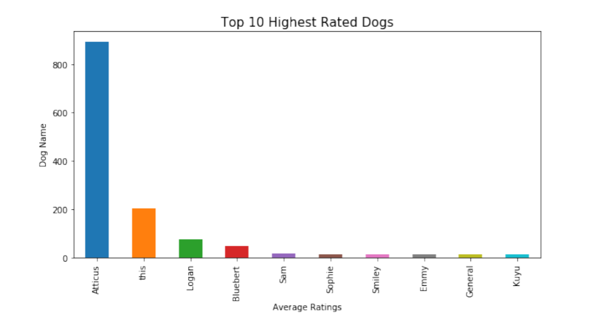

**Atticus** is the winner here! This happened to be the highest rated dog as shown in the above chart. But is Atticus the most liked dog? We'll discover in a moment.

1. Which dogs had the highest favourites (likes)

Though a dog might be highly rated due to some attribute it possesses, or even a very good photoshot. However, being liked might be a very different thing altogether, or maybe not. Let's plot dogs by the likes they got.

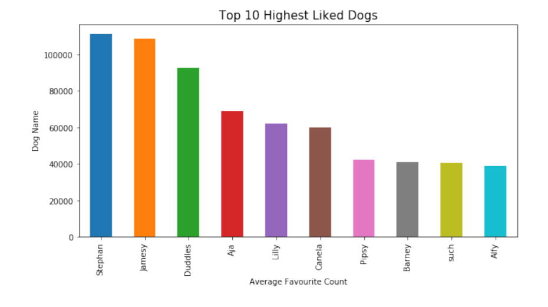

Although this is a close 'competition', **Stephan** was the most liked dog. Atticus who was the highest rated was not even among the top 10! Well, being highly rated might not necessarily translate to being generally liked by all.

1. Which dog_type had the highest favourites (likes)

Among the defined dog types, we had four different ones; **puppo**, **doggo**, **floofer**, and **pupper**. This next analysis will give us insight on which dog types had the highest likes.

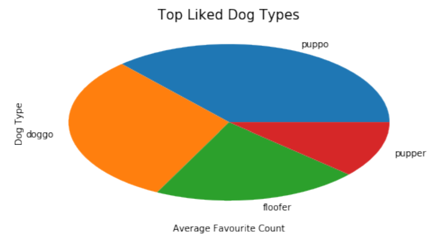

**puppo** was the most liked dog type. Who doesn't like a cute dog?